# Data Analysis

EXPLORATORY DATA ANALYSIS ON THE PLASTIC MANAGEMENT DATASET

## In this study our primary focus would be the concentration of debris on the shores

```python
import pandas as pd

marine = pd.read_csv('C:/Users/Rasha/Downloads/shore_data.csv')
marine.head()
```

|  | list_id | master_item_id | material_index | material | altitude | radius | item_id | id | quantity | latitude | longitude | location | log_index | index | master_name |
| --- | --- | --- | --- | --- | --- | --- | --- | --- | --- | --- | --- | --- | --- | --- | --- |
| 0 | 73 | 6 | 4 | PLASTIC | 10.040165 | 65.0 | 2661 | 1706678 | 1 | 48.429976 | -123.393850 | Victoria, British Columbia, Canada | 43970 | 31 | Cigarettes/Cigars |
| 1 | 73 | 6 | 4 | PLASTIC | 9.715973 | 48.0 | 2661 | 1706679 | 1 | 48.429920 | -123.393839 | Victoria, British Columbia, Canada | 43970 | 32 | Cigarettes/Cigars |
| 2 | 73 | 6 | 4 | PLASTIC | 9.715973 | 48.0 | 2661 | 1706680 | 1 | 48.429920 | -123.393839 | Victoria, British Columbia, Canada | 43970 | 33 | Cigarettes/Cigars |
| 3 | 73 | 6 | 4 | PLASTIC | 9.463489 | 64.0 | 2661 | 1706681 | 1 | 48.429890 | -123.393795 | Victoria, British Columbia, Canada | 43970 | 34 | Cigarettes/Cigars |
| 4 | 73 | 6 | 4 | PLASTIC | 9.463489 | 64.0 | 2661 | 1706682 | 1 | 48.429890 | -123.393795 | Victoria, British Columbia, Canada | 43970 | 35 | Cigarettes/Cigars |

## Cleaning the Data

```python
#removing unwanted columns/features (basic data cleaning)

marine = marine.drop('item_id', axis = 1)
marine = marine.drop('log_index', axis = 1)
marine = marine.drop('id', axis = 1)
marine = marine.drop('index', axis = 1)
```

```python
marine.head()
```

|  | list_id | master_item_id | material_index | material | altitude | radius | quantity | latitude | longitude | location | master_name |
| --- | --- | --- | --- | --- | --- | --- | --- | --- | --- | --- | --- |
| 0 | 73 | 6 | 4 | PLASTIC | 10.040165 | 65.0 | 1 | 48.429976 | -123.393850 | Victoria, British Columbia, Canada | Cigarettes/Cigars |
| 1 | 73 | 6 | 4 | PLASTIC | 9.715973 | 48.0 | 1 | 48.429920 | -123.393839 | Victoria, British Columbia, Canada | Cigarettes/Cigars |
| 2 | 73 | 6 | 4 | PLASTIC | 9.715973 | 48.0 | 1 | 48.429920 | -123.393839 | Victoria, British Columbia, Canada | Cigarettes/Cigars |
| 3 | 73 | 6 | 4 | PLASTIC | 9.463489 | 64.0 | 1 | 48.429890 | -123.393795 | Victoria, British Columbia, Canada | Cigarettes/Cigars |
| 4 | 73 | 6 | 4 | PLASTIC | 9.463489 | 64.0 | 1 | 48.429890 | -123.393795 | Victoria, British Columbia, Canada | Cigarettes/Cigars |

```python
marine.count()

#location column has some missing instances
```

```
list_id           50970
master_item_id    50970
material_index    50970
material          50970
altitude          50970
radius            50970
quantity          50970
latitude          50970
longitude         50970
location          50915
master_name       50970
dtype: int64
```

```python
#The raw data contains 50970 instances and 11 features
marine.shape
```

```
(50970, 11)
```

```python
#data types of the features
marine.dtypes
```

```
list_id             int64
master_item_id      int64
material_index      int64
material           object
altitude          float64
radius            float64
quantity            int64
latitude          float64
longitude         float64
location           object
master_name        object
dtype: object
```

### Our dataset is huge to be compatible for plotting it on the map (keeping in mind the software tool we are using to develop our map). So we would have to resort the way of removing couple of instances from the dataset. We will begin this by looking if any row has missing data, if so then we would remove that row. As we can see from above, around 55 instances are missing from the location column. So initially we would be removing the rows that has missing data (location)

```python
marine_f = marine.dropna(how='any')
marine_f.count()

#dropping the rows that have missing instances
```

```
list_id           50915
master_item_id    50915
material_index    50915
material          50915
altitude          50915
radius            50915
quantity          50915
latitude          50915
longitude         50915
location          50915
master_name       50915
dtype: int64
```

```python
marine_f.shape
```

```
(50915, 11)
```

```python
#Considering only first 4000 rows for compatibility, study and better optimization purposes

marine_f = marine_f.drop(marine_f.index[4000:50915])
marine_f.head()
```

|  | list_id | master_item_id | material_index | material | altitude | radius | quantity | latitude | longitude | location | master_name |
| --- | --- | --- | --- | --- | --- | --- | --- | --- | --- | --- | --- |
| 0 | 73 | 6 | 4 | PLASTIC | 10.040165 | 65.0 | 1 | 48.429976 | -123.393850 | Victoria, British Columbia, Canada | Cigarettes/Cigars |
| 1 | 73 | 6 | 4 | PLASTIC | 9.715973 | 48.0 | 1 | 48.429920 | -123.393839 | Victoria, British Columbia, Canada | Cigarettes/Cigars |
| 2 | 73 | 6 | 4 | PLASTIC | 9.715973 | 48.0 | 1 | 48.429920 | -123.393839 | Victoria, British Columbia, Canada | Cigarettes/Cigars |
| 3 | 73 | 6 | 4 | PLASTIC | 9.463489 | 64.0 | 1 | 48.429890 | -123.393795 | Victoria, British Columbia, Canada | Cigarettes/Cigars |
| 4 | 73 | 6 | 4 | PLASTIC | 9.463489 | 64.0 | 1 | 48.429890 | -123.393795 | Victoria, British Columbia, Canada | Cigarettes/Cigars |

```python
marine_f.shape
```

```
(4000, 11)
```

```python
# Total times the waste have been found in a particular location (the number of times the place is mentioned in our data)

g = marine_f.groupby('location').list_id.count()
g
```

```
location
?????? ?????, Bushehr Province, Iran Province, Iran                   41
Arcata, California, United States of America                          33
Bahía Blanca, Buenos Aires, Argentina                                 57
Batticaloa, Eastern Province, Sri Lanka                               65
Bogota                                                                 8
Buenos Aires, Argentina                                                4
Bushehr Province, Iran                                               100
Cajicá, Colombia                                                       9
Caledon, Ontario, Canada                                              10
Calgary, Alberta, Canada                                               5
Chennai, Tamil Nadu, India                                            13
Chicago, Illinois, United States of America                           91
Coral Springs, Florida, United States of America                       1
Cornwall, England, United Kingdom                                     22
Esquimalt, British Columbia, Canada                                  154
Eureka, California, United States of America                         317
Fort Collins, Colorado, United States of America                       4
Friday Harbor, Washington, United States of America                   92
Gilford, New Hampshire, United States of America                      40
Glynn County, Georgia, United States of America                        1
Guelph, Ontario, Canada                                                7
Hampshire, England, United Kingdom                                     3
Hampton, New Hampshire, United States of America                       8
Hayama, Kanagawa Prefecture, Japan                                    11
Hong Kong Island, Hong Kong                                          680
Islamorada, Village of Islands, Florida, United States of America     28
Jekyll Island, Georgia, United States of America                     484
Kamakura-shi, Kanagawa Prefecture, Japan                              50
Kanayannur, Kerala, India                                             15
Karjat, Maharashtra, India                                            30
Kenosha County, Wisconsin, United States of America                   12
Kos Regional Unit, Aegean, Greece                                      6
Laurel, Mississippi, United States of America                          8
Los Angeles, California, United States of America                    113
Los Gatos, California, United States of America                        3
Malibu, California, United States of America                           9
Manhattan Beach, California, United States of America                 35
Monterey, California, United States of America                        13
Montevideo, Montevideo, Uruguay                                       62
```

[output cut: 10 more lines]

```
San Juan de Miraflores, Lima, Peru                                    54
San Miguel, Lima, Peru                                                15
Santa Fe, Argentina                                                    5
Santa Fe, Santa Fe, Argentina                                          6
Santos, São Paulo, Brazil                                             25
St Lucia, Queensland, Australia                                        5
St. Louis, Missouri, United States of America                         42
Thames-Coromandel District, Waikato Region, New Zealand              246
Thane, Maharashtra, India                                             29
Thiruvananthapuram, Kerala, India                                    137
Tororo, Uganda                                                         7
Victoria, British Columbia, Canada                                   169
Wilmington, North Carolina, United States of America                   3
Ísafjarðarbær, Iceland                                                17
Name: list_id, dtype: int64
```

```python
g.count()

#So there are around 63 places mentioned in our dataset`
```

```
63
```

```python
marine_f.shape
```

```
(4000, 11)
```

### Overall the total number of instances we would be considering is 4000 and 11 features.

### There are 63 places taken into consideration for our study

### The dataset collected, segregates identified marine debris into different kinds of waste (for example : plastic bags, cigars , glass fragments etc) and their origin/material the identified debris is made up of(for example : metal, cloth, plastic,rubber etc )

```python
a = marine_f.groupby('master_name').master_item_id.min()
print('Types of Marine Debris: \n\n',a)
```

```
Types of Marine Debris:

 master_name
Aerosol cans                            16
Aluminum Foil                           50
Aluminum or Tin Cans                    17
Aquaculture Gear                       132
Balloon and/or String                    2
Batteries                               43
Bolts, Nails, & Screws                 112
Buoys and floats                        32
Cigarettes/Cigars                        6
Clothing and Shoes                      23
Coated Paperboard Container            100
Diapers                                 59
Dump Site                              125
E-Waste Fragments                      114
Electronics and Appliances              79
Fabric pieces                           24
Face shield                            145
Fireworks                               83
Fishing Line                           137
Fishing Net                             85
Fishing Traps                           39
Fishing lures and lines                 33
Flip-flops                              21
Foam Fragment                          129
Foam or Plastic Cups or Plates           7
Foam or Plastic Food Containers         49
Furniture                               90
Glass Bottle                            19
Glass Fragments                         92
Gun Shells                              93
Hair net                               146
Hand sanitizer                         147
Informal Recycling Sector              123
Landmark                                46
Light Bulbs or Tubes                    91
Lobster Claw Bands                      68
Lumber/Building Materials               28
```

[output cut: 36 more lines]

```
Rubber Fragments                        67
Rubber Gloves                            9
Shoe covers                            150
Six-pack rings                          14
Store                                  121
Storm Water Infrastructure             124
Straws                                  15
Syringes                                60
Tires                                   22
Tobacco Packaging or Lighters            5
Towels or rags                          26
Toys                                    44
Waste Receptacle                        38
Wipes                                  139
Name: master_item_id, dtype: int64
```

```python
c_classes = a.count()
print('Total types of Marine Debris from our dataset = ',c_classes)
```

```
Total types of Marine Debris from our dataset =  87
```

### Our dataset contains 87 kinds of marine debris/the kind of waste identified

```python
b = marine.groupby('material').material_index.min()
b
```

```
material
BOAT PARTS        6
CLOTH             7
FISHING GEAR      3
GLASS             5
METAL             2
OTHER ITEMS       1
Other items       1
PAPER & LUMBER    8
PLASTIC           4
RUBBER            9
Name: material_index, dtype: int64
```

```python
b.count()
```

```
10
```

### Each of the identified marine debris falls into one of the 9 classes. These 9 classes gives us an insight of the background of the type of marine debris identified, i.e it tells us the origin or the type of material , a particular identified debris is made up of. For example : If my identified waste is a soda can, then this waste falls under the metallic class.

### Feature Description :

### list_id : id given to the places where the debris was found

### master_item_id : ID given to the kind of debris found (example : cigars, can bottles etc)

### material_index : index of the class (1-9 range)

### latitude : latitude of the place where debris was found

### longitude : longitude of the place where debris was found

### master_name : The type of waste identified

### Material : Origin/material of the type of waste identified

## Data Analysis

```python
marine_f.head()
```

|  | list_id | master_item_id | material_index | material | altitude | radius | quantity | latitude | longitude | location | master_name |
| --- | --- | --- | --- | --- | --- | --- | --- | --- | --- | --- | --- |
| 0 | 73 | 6 | 4 | PLASTIC | 10.040165 | 65.0 | 1 | 48.429976 | -123.393850 | Victoria, British Columbia, Canada | Cigarettes/Cigars |
| 1 | 73 | 6 | 4 | PLASTIC | 9.715973 | 48.0 | 1 | 48.429920 | -123.393839 | Victoria, British Columbia, Canada | Cigarettes/Cigars |
| 2 | 73 | 6 | 4 | PLASTIC | 9.715973 | 48.0 | 1 | 48.429920 | -123.393839 | Victoria, British Columbia, Canada | Cigarettes/Cigars |
| 3 | 73 | 6 | 4 | PLASTIC | 9.463489 | 64.0 | 1 | 48.429890 | -123.393795 | Victoria, British Columbia, Canada | Cigarettes/Cigars |
| 4 | 73 | 6 | 4 | PLASTIC | 9.463489 | 64.0 | 1 | 48.429890 | -123.393795 | Victoria, British Columbia, Canada | Cigarettes/Cigars |

```python
marine_f.shape
```

```
(4000, 11)
```

```python
# Our first step in the analysis part would be finding out, the concentration of the waste material, i.e finding out which class of material has the highest concentration
marine_f.groupby('material').master_name.count()
```

```
material
BOAT PARTS          31
CLOTH              249
FISHING GEAR       191
GLASS               80
METAL              181
OTHER ITEMS        739
Other items        107
PAPER & LUMBER     271
PLASTIC           2147
RUBBER               4
Name: master_name, dtype: int64
```

### As you can see from above most of the identified waste were made of plastic, so basically plastic tops the chart followed by other items and paper and lumber. Also the concentration of plastic wastes observed is more than the overall sum of the concentration of other kind of materials combined

```python
pd.set_option('display.max_rows', None)
plas = marine_f.loc[marine_f.material=='PLASTIC','master_name']
plas
```

```
0                    Cigarettes/Cigars
1                    Cigarettes/Cigars
2                    Cigarettes/Cigars
3                    Cigarettes/Cigars
4                    Cigarettes/Cigars
5                    Cigarettes/Cigars
6                    Cigarettes/Cigars
7                Plastic Food Wrappers
9                         Fishing Line
10       Tobacco Packaging or Lighters
11           Plastic or Foam Fragments
12                   Cigarettes/Cigars
13                   Cigarettes/Cigars
14                   Cigarettes/Cigars
15                   Cigarettes/Cigars
```

[output cut: 23 more lines]

```python
plas.count()
```

```
2147
```

## ● Analyzing the Concetration of different materials in the debris

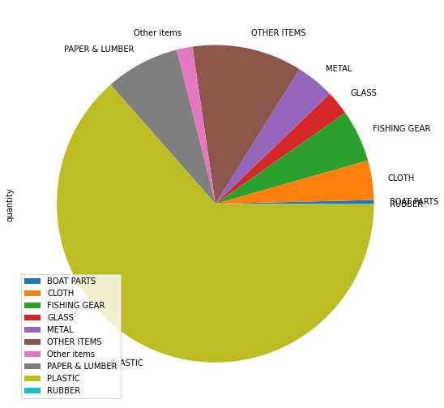

```python
piv_loc = piv_loc.pivot_table(index = "material", aggfunc = "sum")
piv_loc
plot = piv_loc.plot.pie(y='quantity', figsize=(9,9))
```

### The above pie chart gives us a clear understanding that plastic contributes to most of the debris wastes in the shores whereas boart parts and rubber consumes the least

### Since plastic contributed towards the major portion of debris identified, we will switch our focus towards the kinds of plastic wastes identified

```python
pd.set_option('display.max_rows', None)
plas = marine_f.loc[marine_f.material=='PLASTIC','master_name']
plas
type(plas)
plas_count = plas.value_counts()
plas_count
```

```
Cigarettes/Cigars                 589
Plastic or Foam Fragments         352
Plastic Food Wrappers             271
Plastic Caps or Lids              156
Other Rubber                      142
Plastic Bags                      102
Plastic Bottle                     86
Foam or Plastic Cups or Plates     66
Straws                             57
Tobacco Packaging or Lighters      55
Plastic Utensils                   49
Foam Fragment                      49
Rubber Gloves                      46
Personal Care Products             42
Other Plastic Jugs                 21
Balloon and/or String              20
Toys                               17
Rubber Fragments                   14
Fishing Line                        8
Rubber Bands                        2
Six-pack rings                      2
Aquaculture Gear                    1
Name: master_name, dtype: int64
```

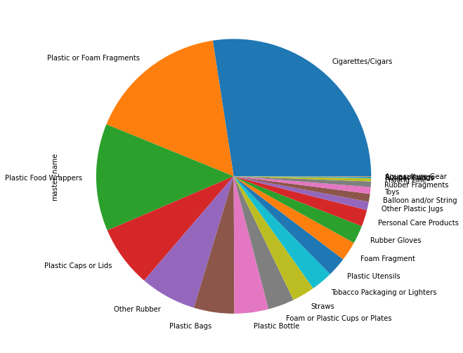

```python
plas_count.plot(kind = 'pie', figsize=(9,9))
```

## ● Analyzing the Concetration of wastes in different places

```python
pd.set_option('display.max_rows', None)
locat = marine_f['location'].value_counts()
locat
```

```
Hong Kong Island, Hong Kong                                          680
Jekyll Island, Georgia, United States of America                     484
San Diego, California, United States of America                      324
Eureka, California, United States of America                         317
Thames-Coromandel District, Waikato Region, New Zealand              246
Rehoboth Beach, Delaware, United States of America                   229
Victoria, British Columbia, Canada                                   169
Esquimalt, British Columbia, Canada                                  154
Thiruvananthapuram, Kerala, India                                    137
Los Angeles, California, United States of America                    113
Bushehr Province, Iran                                               100
Friday Harbor, Washington, United States of America                   92
Chicago, Illinois, United States of America                           91
Batticaloa, Eastern Province, Sri Lanka                               65
Montevideo, Montevideo, Uruguay                                       62
Bahía Blanca, Buenos Aires, Argentina                                 57
San Juan de Miraflores, Lima, Peru                                    54
Kamakura-shi, Kanagawa Prefecture, Japan                              50
St. Louis, Missouri, United States of America                         42
?????? ?????, Bushehr Province, Iran Province, Iran                   41
Gilford, New Hampshire, United States of America                      40
Manhattan Beach, California, United States of America                 35
Arcata, California, United States of America                          33
Karjat, Maharashtra, India                                            30
Thane, Maharashtra, India                                             29
Islamorada, Village of Islands, Florida, United States of America     28
Santos, São Paulo, Brazil                                             25
Cornwall, England, United Kingdom                                     22
Ísafjarðarbær, Iceland                                                17
San Miguel, Lima, Peru                                                15
Kanayannur, Kerala, India                                             15
Chennai, Tamil Nadu, India                                            13
Monterey, California, United States of America                        13
Kenosha County, Wisconsin, United States of America                   12
Pará, Brazil                                                          12
Hayama, Kanagawa Prefecture, Japan                                    11
Caledon, Ontario, Canada                                              10
Malibu, California, United States of America                           9
Cajicá, Colombia                                                       9
Orleans, Massachusetts, United States of America                       9
```

[output cut: 9 more lines]

```
Calgary, Alberta, Canada                                               5
St Lucia, Queensland, Australia                                        5
Santa Fe, Argentina                                                    5
Rockingham County, New Hampshire, United States of America             5
Fort Collins, Colorado, United States of America                       4
Buenos Aires, Argentina                                                4
Wilmington, North Carolina, United States of America                   3
Los Gatos, California, United States of America                        3
Hampshire, England, United Kingdom                                     3
Rethymno Regional Unit, Region of Crete, Greece                        2
Rawson, Chubut, Argentina                                              1
Coral Springs, Florida, United States of America                       1
Glynn County, Georgia, United States of America                        1
Raritan, New Jersey, United States of America                          1
Name: location, dtype: int64
```

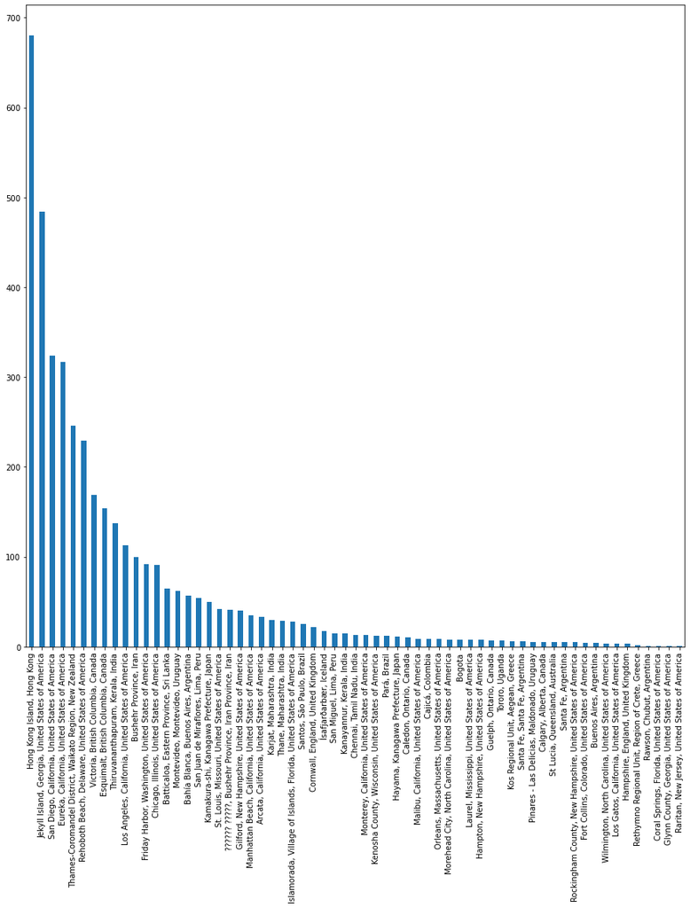

```python
locat.plot(kind = 'bar',figsize=(15,15))
```

### Above bar charts shows us the segreation of debris distribution across different place. The maximum number of the wastes were taken from Hong Kong Island

```python
#displaying the 9 classes of debris materials

b
```

```
material
BOAT PARTS        6
CLOTH             7
FISHING GEAR      3
GLASS             5
METAL             2
OTHER ITEMS       1
Other items       1
PAPER & LUMBER    8
PLASTIC           4
RUBBER            9
Name: material_index, dtype: int64
```

```python
marine_f[(marine_f.location == "Hong Kong Island, Hong Kong")& (marine_f.material == "PLASTIC")]
```

|  | list_id | master_item_id | material_index | material | altitude | radius | quantity | latitude | longitude | location | master_name |
| --- | --- | --- | --- | --- | --- | --- | --- | --- | --- | --- | --- |
| 180 | 22 | 9 | 4 | PLASTIC | 30.070275 | 45.144410 | 1 | 22.240211 | 114.221379 | Hong Kong Island, Hong Kong | Rubber Gloves |
| 181 | 22 | 9 | 4 | PLASTIC | 23.992261 | 36.016896 | 1 | 22.240197 | 114.221388 | Hong Kong Island, Hong Kong | Rubber Gloves |
| 344 | 22 | 3 | 4 | PLASTIC | 36.999851 | 65.000000 | 1 | 22.238170 | 114.224009 | Hong Kong Island, Hong Kong | Plastic Bottle |
| 345 | 22 | 4 | 4 | PLASTIC | 36.999851 | 65.000000 | 1 | 22.238170 | 114.224009 | Hong Kong Island, Hong Kong | Plastic Caps or Lids |
| 346 | 22 | 6 | 4 | PLASTIC | 36.999851 | 65.000000 | 1 | 22.238170 | 114.224009 | Hong Kong Island, Hong Kong | Cigarettes/Cigars |
| 347 | 22 | 1 | 4 | PLASTIC | 36.999851 | 65.000000 | 1 | 22.238170 | 114.224009 | Hong Kong Island, Hong Kong | Plastic Bags |
| 348 | 22 | 1 | 4 | PLASTIC | 36.999851 | 65.000000 | 1 | 22.238170 | 114.224009 | Hong Kong Island, Hong Kong | Plastic Bags |
| 349 | 22 | 1 | 4 | PLASTIC | 36.999851 | 65.000000 | 1 | 22.238170 | 114.224009 | Hong Kong Island, Hong Kong | Plastic Bags |
| 350 | 22 | 7 | 4 | PLASTIC | 36.999851 | 65.000000 | 1 | 22.238170 | 114.224009 | Hong Kong Island, Hong Kong | Foam or Plastic Cups or Plates |
| 351 | 22 | 13 | 4 | PLASTIC | 36.999851 | 65.000000 | 1 | 22.238170 | 114.224009 | Hong Kong Island, Hong Kong | Plastic Utensils |
| 358 | 22 | 6 | 4 | PLASTIC | 63.651306 | 5.000000 | 1 | 22.235862 | 114.222966 | Hong Kong Island, Hong Kong | Cigarettes/Cigars |
| 359 | 22 | 1 | 4 | PLASTIC | 62.068604 | 5.000000 | 1 | 22.235862 | 114.222966 | Hong Kong Island, Hong Kong | Plastic Bags |
| 360 | 22 | 1 | 4 | PLASTIC | 62.068481 | 5.000000 | 1 | 22.235862 | 114.222966 | Hong Kong Island, Hong Kong | Plastic Bags |
| 362 | 22 | 15 | 4 | PLASTIC | 60.131398 | 5.000000 | 1 | 22.235771 | 114.223023 | Hong Kong Island, Hong Kong | Straws |
| 363 | 22 | 15 | 4 | PLASTIC | 60.131398 | 5.000000 | 1 | 22.235771 | 114.223023 | Hong Kong Island, Hong Kong | Straws |
| 364 | 22 | 1 | 4 | PLASTIC | 54.620477 | 5.000000 | 1 | 22.235715 | 114.223058 | Hong Kong Island, Hong Kong | Plastic Bags |
| 366 | 22 | 6 | 4 | PLASTIC | 42.094604 | 5.000000 | 1 | 22.234628 | 114.223350 | Hong Kong Island, Hong Kong | Cigarettes/Cigars |
| 367 | 22 | 6 | 4 | PLASTIC | 40.014596 | 5.000000 | 2 | 22.234442 | 114.223357 | Hong Kong Island, Hong Kong | Cigarettes/Cigars |
| 368 | 22 | 15 | 4 | PLASTIC | 39.958242 | 5.000000 | 1 | 22.234382 | 114.223296 | Hong Kong Island, Hong Kong | Straws |
| 375 | 22 | 8 | 4 | PLASTIC | 8.474743 | 5.000000 | 1 | 22.233113 | 114.223628 | Hong Kong Island, Hong Kong | Plastic Food Wrappers |
| 377 | 22 | 6 | 4 | PLASTIC | 8.661757 | 5.000000 | 1 | 22.233126 | 114.223647 | Hong Kong Island, Hong Kong | Cigarettes/Cigars |
| 378 | 22 | 6 | 4 | PLASTIC | 8.594478 | 5.000000 | 1 | 22.233132 | 114.223632 | Hong Kong Island, Hong Kong | Cigarettes/Cigars |
| 379 | 22 | 6 | 4 | PLASTIC | 7.106988 | 5.000000 | 1 | 22.233136 | 114.223622 | Hong Kong Island, Hong Kong | Cigarettes/Cigars |
| 380 | 22 | 6 | 4 | PLASTIC | 6.070076 | 5.000000 | 1 | 22.233126 | 114.223619 | Hong Kong Island, Hong Kong | Cigarettes/Cigars |
| 381 | 22 | 6 | 4 | PLASTIC | 5.392710 | 5.000000 | 1 | 22.233169 | 114.223621 | Hong Kong Island, Hong Kong | Cigarettes/Cigars |
| 382 | 22 | 6 | 4 | PLASTIC | 5.392710 | 5.000000 | 1 | 22.233169 | 114.223621 | Hong Kong Island, Hong Kong | Cigarettes/Cigars |
| 384 | 22 | 4 | 4 | PLASTIC | 7.754056 | 5.000000 | 1 | 22.233177 | 114.223615 | Hong Kong Island, Hong Kong | Plastic Caps or Lids |
| 385 | 22 | 4 | 4 | PLASTIC | 5.299555 | 5.000000 | 1 | 22.233176 | 114.223587 | Hong Kong Island, Hong Kong | Plastic Caps or Lids |
| 386 | 22 | 3 | 4 | PLASTIC | 5.000680 | 5.000000 | 1 | 22.233176 | 114.223587 | Hong Kong Island, Hong Kong | Plastic Bottle |
| 387 | 22 | 6 | 4 | PLASTIC | 5.804952 | 5.000000 | 1 | 22.233195 | 114.223563 | Hong Kong Island, Hong Kong | Cigarettes/Cigars |

[output cut: 336 more lines]